# Alpha diversity

Diversity within a single sample

Monday, September 28, 2026

## Alpha diversity

Measures diversity **within a single sample**

Captures two key aspects:

- **Richness:** how many unique species are present
- **Evenness:** how evenly distributed they are

## Counting richness and evenness

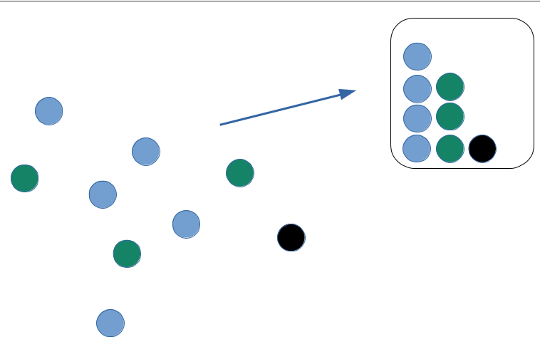

## Richness versus evenness

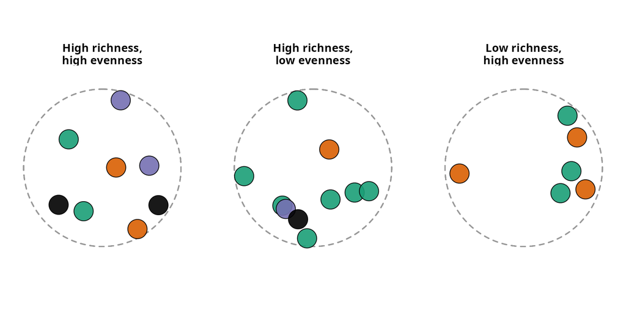

## Finite sampling

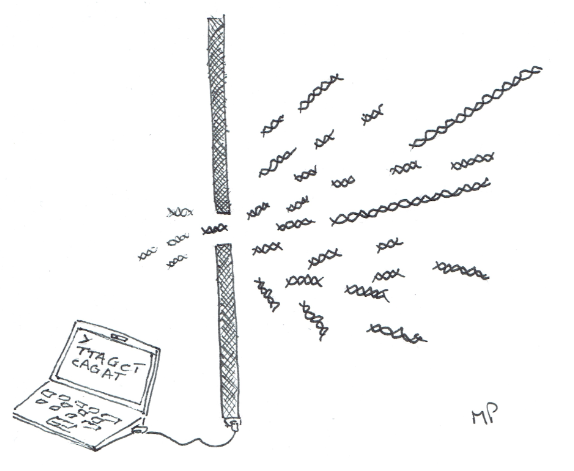

Source: github.com/mblstamps/stamps2019

## Applications

Alpha diversity, ageing and body-mass index across the life span.

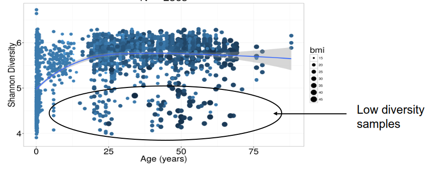

Data: HITChip Atlas, [Lahti et al. Nat Comm 2014](https://doi.org/10.1038/ncomms5344)

## Applications

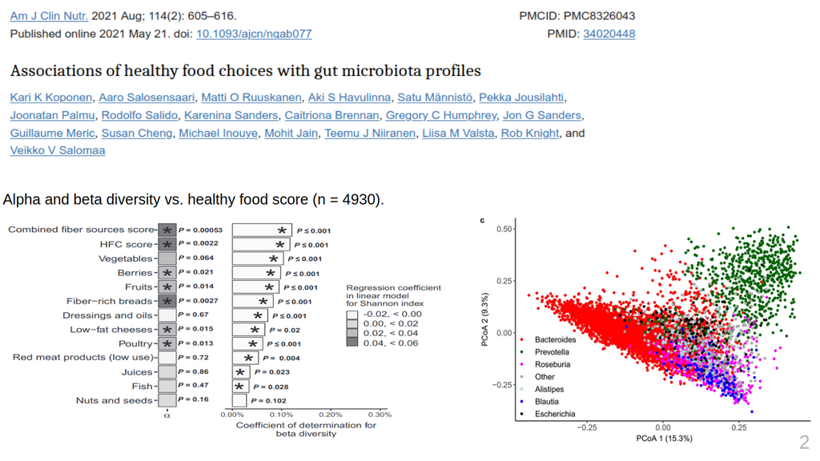

## Richness

$$R = \text{Number of unique species}$$

**Observed richness**

- Counting the number of unique species

**True richness** to be estimated based on a finite sample (Sanders, 1968)

- Chao1: more sensitive to sampling effort
- ACE: more stable, emphasizes information from rare taxa

## Shannon diversity

$$H' = - \sum_{i=1}^{R} p_i \log(p_i)$$

*where:*

- $p_i$ = relative abundance of species $i$
- $R$ = total number of species

Combines richness and evenness in one metric.

## Pielou’s evenness

$$E = \frac{Shannon\ diversity}{ln(Obs.\ Richness)} = \frac{H}{ln(S)}$$

## Berger-Parker dominance

Maximum relative abundance in the sample; or relative abundance $p_i$ of the most abundant type.

$$max_i (p_i)$$

## Simpson’s dominance index

Simpson index $\lambda$ measures how likely two randomly picked individuals represent the same species.

$$\lambda = \sum_{i=1}^{R} p_i^2$$

*where:*

- $p_i$ = relative abundance of species $i$
- $R$ = richness, or the number of unique species

## Simpson’s diversity?

However, the original Simpson index $\lambda$ decreases with diversity. Therefore we typically use:

- Inverse Simpson: $1 / \lambda$ (the most common case of Simpson’s diversity)
- Reciprocal Simpson (or Gini-Simpson): $1 - \lambda$

## Hill’s diversity: a unifying concept

True diversity, the effective number of types, refers to the number of equally abundant types needed for the average proportional abundance of the types to equal what is observed in the dataset of interest.

$$^qD = \frac{1}{M_{q-1}} = (\sum_{i=1}^R p_i^q)^\frac{1}{1-q},$$

where (again)

- $p_i$ is relative abundance of species $i$,
- $R$ is the richness (number of species)
- $q^D$ is the Hill number of order $q$, the effective number of species
- Denominator $M_{q-1}$: average relative abundance, with weighted generalized mean with exponent $q − 1$.

## Hill’s diversity: a unifying concept

Common diversity measures are special cases:

- $q = 0$: Observed Richness
- $q = 1$: Shannon diversity
- $q = 2$: (Inverse) Simpson diversity
- $q ≠ 1$: Renyi entropy
- $q = \infty$: $\frac{1}{{^{\infty}}D}$: Berger-Parker index

## Faith phylogenetic diversity

Faith index incorporates phylogenetic differences (tree) to diversity: sum of branch lengths in a phylogenetic tree that connects all species present in a sample.

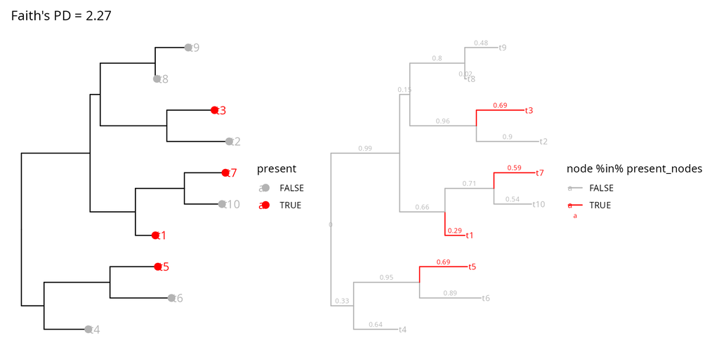

## Faith phylogenetic diversity

Phylogenetic diversity provides increased statistical power to differentiate age groups in shotgun metagenomics but not in 16S rRNA sequencing.

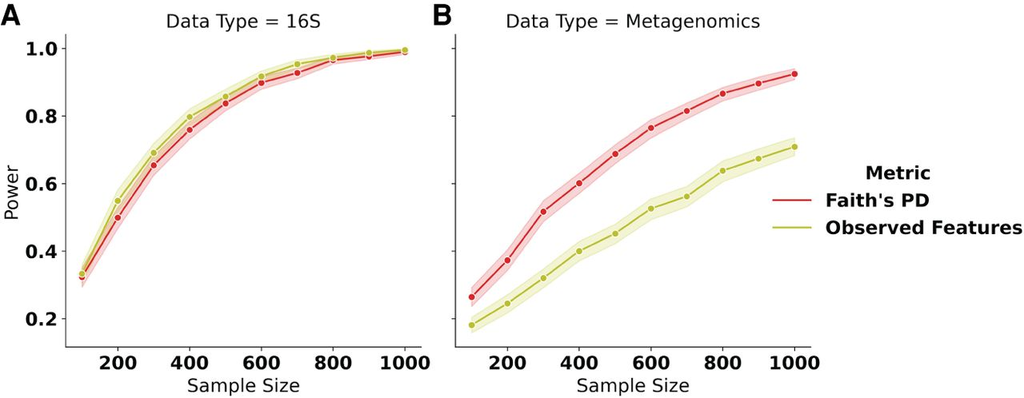

Armstrong et al. (2021), Genome Research.

## Faith phylogenetic diversity

Phylogenetic tree colored by age-group log of the likelihood ratio of older to younger adults per node.

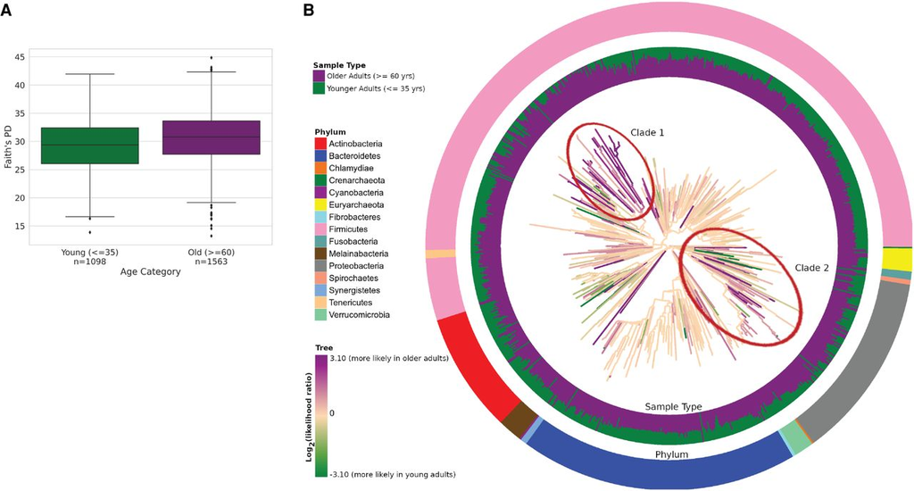

(*A*) Distribution of Faith’s PD by age group on the full data set.

(*B*) Web of Life (WoL) phylogenetic tree, branches colored by log likelihood of old vs. young adults (**FINRISK cohort**).

Armstrong et al. (2021), Genome Research.

## Fast Faith implementation

Efficient computation of Faith’s phylogenetic diversity with applications in characterizing microbiomes.

TreeSE (gray) versus phyloseq (black)

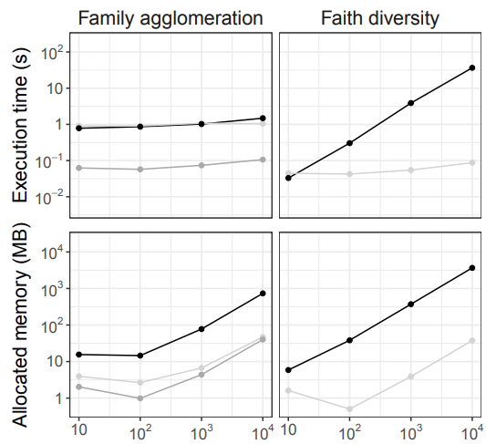

Armstrong et al. (2021), Genome Research.

## Recommendation

Guidelines for alpha diversity, to capture complementary views: Cassol, Ibañez, and Bustamante (2025)

- **Richness:** number of observed unique species
- **Dominance:** Berger-Parker
- **Information:** Shannon
- **Phylogenetics:** Faith

## Demonstration

```r
library(mia)
tse <- addAlpha(tse)
```

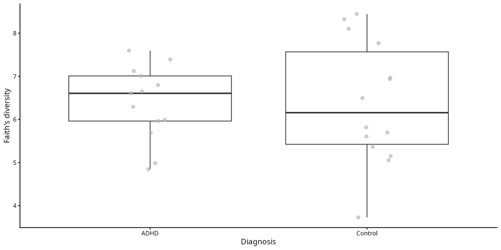

```r
library(mia)
tse <- addAlpha(tse)

library(miaViz)
plotBoxplot(tse, col.var = "faith_diversity", x = "patient_status") +
    labs(x = "Diagnosis", y = "Faith's diversity")
```

## Exercises

**OMA online book, Chapter 13: Alpha diversity**

[microbiome.github.io/OMA › Alpha diversity](https://microbiome.github.io/OMA/docs/devel/pages/alpha_diversity.html)

Exercises **1.2, 1.3, 1.4, 1.9, 1.10**

## Metacommunity and total richness

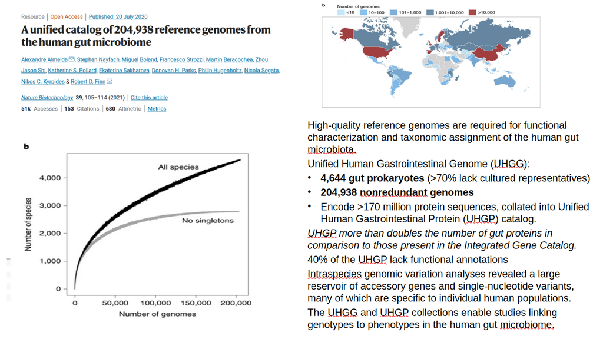

## Detecting species in metagenomics

[figure not shown]

## On reference databases

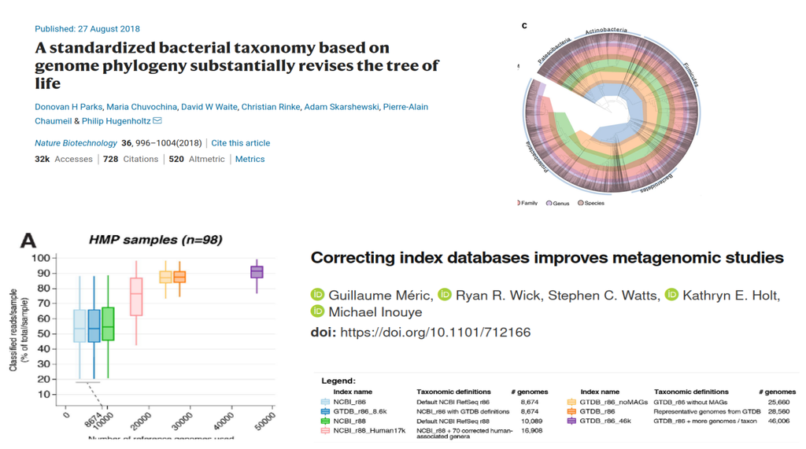

## References

Cassol, Ignacio, Mauro Ibañez, and Juan Pablo Bustamante. 2025. “Key Features and Guidelines for the Application of Microbial Alpha Diversity Metrics.” *Scientific Reports* 15 (1). https://doi.org/10.1038/s41598-024-77864-y.

## Beta diversity revisited

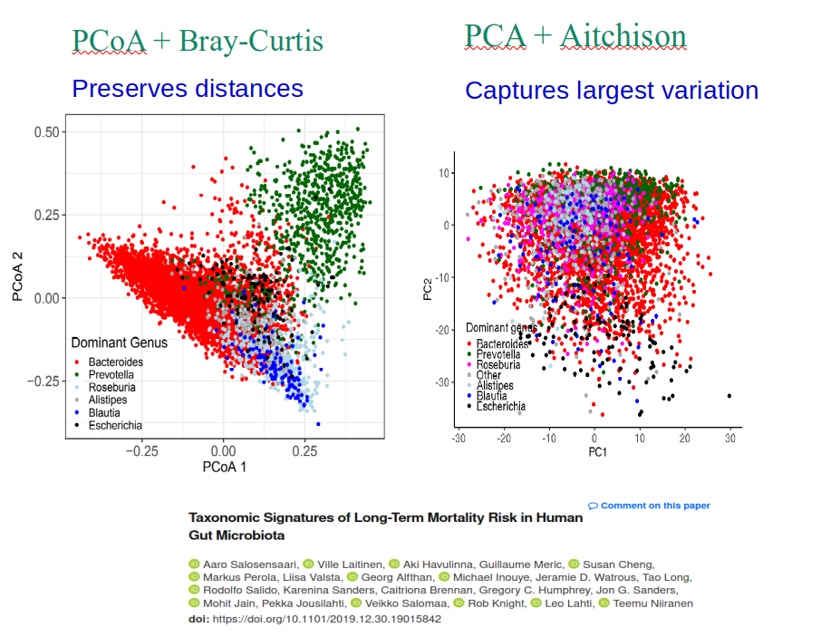